# Danish Kings

Philip Moltke-Leth

2026-03-12

```r
library(tidyverse)
```

The task here is to load your Danish Monarchs csv into R using the `tidyverse` toolkit, calculate and explore the kings’ duration of reign with pipes `%>%` in `dplyr` and plot it over time.

## Load the kings

Make sure to first create an `.Rproj` workspace with a `data/` folder where you place either your own dataset or the provided `kings.csv` dataset.

1. Look at the dataset that are you loading and check what its columns are separated by? (hint: open it in plain text editor to see)

List what is the separator: , (comma)

2. Create a `kings` object in R with the different functions below and inspect the different outputs.
- `read.csv()`
- `read_csv()`
- `read.csv2()`
- `read_csv2()`

```r
# FILL IN THE CODE BELOW and review the outputs
kings1 <- read.csv("data/kings.csv")

kings2 <- read_csv("data/kings.csv", show_col_types = FALSE)

kings3 <- read.csv2("data/kings.csv")

kings4 <- read_csv2( "data/kings.csv", show_col_types = FALSE)
```

[output not shown]

Answer: 1. Which of these functions is a `tidyverse` function? Read data with it below into a `kings` object

```r
kings <- read_csv("data/kings.csv", show_col_types = FALSE)
```

A: read_csv() is a tidyverse function.

2. What is the result of running `class()` on the `kings` object created with a tidyverse function.

```r
class(kings)
```

```
## [1] "spec_tbl_df" "tbl_df"      "tbl"         "data.frame"
```

A: The result of running `class(kings)` shows that the object is a tibble (`spec_tbl_df`, `tbl_df`, `tbl`, `data.frame`).

3. How many columns does the object have when created with these different functions?

```r
ncol(kings)
```

```
## [1] 11
```

A: The dataset contains 11 columns when read with read_csv() and read.csv(), but only 1 column when read with read.csv2() and read_csv2() because those use a semicolon separater.

4. Show the dataset so that we can see how R interprets each column

```r
glimpse(kings)
```

```
## Rows: 57
## Columns: 11
## $ Name       <chr> "Gorm den Gamle", "Harald 1. Blåtand", "Toke_Gormsen", "Sve…
## $ House      <chr> "Gorm", "Gorm", "Gorm", "Gorm", "Gorm", "Gorm", "Gorm", "Fa…
## $ Start_year <chr> "936", "NULL", "985", "NULL", "1014", "1018", "1035", "1042…
## $ End_year   <chr> "958", "NULL", "986", "NULL", "1018", "1035", "1042", "1047…
## $ Birth_year <chr> "908", "936", "NULL", "NULL", "963", "NULL", "995", "1018",…
## $ Death_year <chr> "958", "985", "986", "1014", "NULL", "1035", "1042", "1047"…
## $ Gender     <chr> "M", "M", "M", "M", "M", "M", "M", "M", "M", "M", "M", "M",…
## $ Dynasty    <chr> "Jellingdynastiet", "Jellingdynastiet", "Jellingdynastiet",…
## $ Source     <chr> "https://da.wikipedia.org/wiki/Gorm_den_Gamle", "https://da…
## $ BirthDMY   <chr> "908", "936", NA, "17/04/963", "994", "995", "1018", "1024"…
## $ DeathDMY   <chr> "958", "987", NA, "03/02/1014", "1018", "12/11/1035", "08/0…
```

A: glimpse(kings) shows that all the columns are interpreted as char variables ()

```r
# COMPLETE THE BLANKS BELOW WITH YOUR CODE, then turn the 'eval' flag in this chunk to TRUE.

kings <- read_csv("data/kings.csv")
class(kings)
```

```
## [1] "spec_tbl_df" "tbl_df"      "tbl"         "data.frame"
```

```r
ncol(kings)
```

```
## [1] 11
```

```r
glimpse(kings)
```

```
## Rows: 57
## Columns: 11
## $ Name       <chr> "Gorm den Gamle", "Harald 1. Blåtand", "Toke_Gormsen", "Sve…
## $ House      <chr> "Gorm", "Gorm", "Gorm", "Gorm", "Gorm", "Gorm", "Gorm", "Fa…
## $ Start_year <chr> "936", "NULL", "985", "NULL", "1014", "1018", "1035", "1042…
## $ End_year   <chr> "958", "NULL", "986", "NULL", "1018", "1035", "1042", "1047…
## $ Birth_year <chr> "908", "936", "NULL", "NULL", "963", "NULL", "995", "1018",…
## $ Death_year <chr> "958", "985", "986", "1014", "NULL", "1035", "1042", "1047"…
## $ Gender     <chr> "M", "M", "M", "M", "M", "M", "M", "M", "M", "M", "M", "M",…
## $ Dynasty    <chr> "Jellingdynastiet", "Jellingdynastiet", "Jellingdynastiet",…
## $ Source     <chr> "https://da.wikipedia.org/wiki/Gorm_den_Gamle", "https://da…
## $ BirthDMY   <chr> "908", "936", NA, "17/04/963", "994", "995", "1018", "1024"…
## $ DeathDMY   <chr> "958", "987", NA, "03/02/1014", "1018", "12/11/1035", "08/0…
```

## Calculate the duration of reign for all the kings in your table

You can calculate the duration of reign in years with `mutate` function by subtracting the equivalents of your `startReign` from `endReign` columns and writing the result to a new column called `duration`. But first you need to check a few things:

- Is your data messy? Fix it before re-importing to R
- Do your start and end of reign columns contain NAs? Choose the right strategy to deal with them: `na.omit()`, `na.rm=TRUE`, `!is.na()`

Create a new column called `duration` in the kings dataset, utilizing the `mutate()` function from tidyverse. Check with your group to brainstorm the options.

A: A new column called duration is created by subtracting Start_year from End_year.

```r
kings <- kings %>%
  mutate(
    Start_year = as.numeric(Start_year),
    End_year = as.numeric(End_year),
    duration = End_year - Start_year
  )
```

```r
glimpse(kings)
```

```
## Rows: 57
## Columns: 12
## $ Name       <chr> "Gorm den Gamle", "Harald 1. Blåtand", "Toke_Gormsen", "Sve…
## $ House      <chr> "Gorm", "Gorm", "Gorm", "Gorm", "Gorm", "Gorm", "Gorm", "Fa…
## $ Start_year <dbl> 936, NA, 985, NA, 1014, 1018, 1035, 1042, 1047, 1074, 1080,…
## $ End_year   <dbl> 958, NA, 986, NA, 1018, 1035, 1042, 1047, 1074, 1080, 1086,…
## $ Birth_year <chr> "908", "936", "NULL", "NULL", "963", "NULL", "995", "1018",…
## $ Death_year <chr> "958", "985", "986", "1014", "NULL", "1035", "1042", "1047"…
## $ Gender     <chr> "M", "M", "M", "M", "M", "M", "M", "M", "M", "M", "M", "M",…
## $ Dynasty    <chr> "Jellingdynastiet", "Jellingdynastiet", "Jellingdynastiet",…
## $ Source     <chr> "https://da.wikipedia.org/wiki/Gorm_den_Gamle", "https://da…
## $ BirthDMY   <chr> "908", "936", NA, "17/04/963", "994", "995", "1018", "1024"…
## $ DeathDMY   <chr> "958", "987", NA, "03/02/1014", "1018", "12/11/1035", "08/0…
## $ duration   <dbl> 22, NA, 1, NA, 4, 17, 7, 5, 27, 6, 6, 9, 8, 30, 3, 9, 11, 2…
```

## Calculate the average duration of reign for all rulers

Do you remember how to calculate an average on a vector object? If not, review the last two lessons and remember that a column is basically a vector. So you need to subset your `kings` dataset to the `duration` column. If you subset it as a vector you can calculate average on it with `mean()` base-R function. If you subset it as a tibble, you can calculate average on it with `summarize()` tidyverse function. Try both ways!

- You first need to know how to select the relevant `duration` column. What are your options?
- Is your selected `duration` column a tibble or a vector? The `mean()` function can only be run on a vector. The `summarize()` function works on a tibble.
- Are you getting an error that there are characters in your column? Coerce your data to numbers with `as.numeric()`.
- Remember to handle NAs: `mean(X, na.rm=TRUE)`

```r
mean(kings$duration, na.rm = TRUE)
```

```
## [1] 19.57692
```

## How many and which kings enjoyed a longer-than-average duration of reign?

You have calculated the average duration above. Use it now to `filter()` the `duration` column in `kings` dataset. Display the result and also count the resulting rows with `count()`

```r
avg_duration <- mean(kings$duration, na.rm = TRUE)

longer <- kings %>%
  filter(duration > avg_duration)

print(longer, n = 25)
```

```
## # A tibble: 25 × 12
##    Name    House Start_year End_year Birth_year Death_year Gender Dynasty Source
##    <chr>   <chr>      <dbl>    <dbl> <chr>      <chr>      <chr>  <chr>   <chr>
##  1 Gorm d… Gorm         936      958 908        958        M      Jellin… https…
##  2 Svend … Estr…       1047     1074 1024       1076       M      <NA>    https…
##  3 Niels   Estr…       1104     1134 1055       1134       M      Jellin… https…
##  4 Valdem… Estr…       1157     1182 1131       1182       M      Jellin… https…
##  5 Knud 4. Estr…       1182     1202 1163       1202       M      Jellin… https…
##  6 Valdem… Estr…       1202     1241 1170       1241       M      Jellin… https…
##  7 Erik 5… Estr…       1259     1286 1249       1286       M      Jellin… https…
##  8 Erik 6… Estr…       1286     1319 1274       1319       M      Jellin… https…
##  9 Valdem… Estr…       1340     1375 1320       1375       M      Jellin… https…
## 10 Erik 7… Pome…       1396     1439 1382       1459       M      Jellin… https…
## 11 Chrsti… Olde…       1448     1481 1426       1481       M      Oldenb… https…
## 12 Hans    Olde…       1482     1513 1455       1513       M      Oldenb… https…
## 13 Christ… Olde…       1536     1559 1503       1559       M      Oldenb… https…
## 14 Freder… Olde…       1559     1588 1534       1588       M      Oldenb… https…
## 15 Christ… Olde…       1588     1648 1577       1648       M      Oldenb… https…
## 16 Freder… Olde…       1648     1670 1609       1670       M      Oldenb… https…
## 17 Christ… Olde…       1670     1699 1646       1699       M      Oldenb… https…
## 18 Freder… Olde…       1699     1730 1671       1733       M      Oldenb… https…
## 19 Freder… Olde…       1746     1766 1723       1766       M      Oldenb… https…
## 20 Christ… Olde…       1766     1808 1749       1808       M      Oldenb… https…
## 21 Freder… Olde…       1808     1839 1768       1839       M      Oldenb… https…
## 22 Christ… Schl…       1863     1906 1818       1906       M      Glücks… https…
## 23 Christ… Schl…       1912     1947 1870       1947       M      Glücks… https…
## 24 Freder… Schl…       1947     1972 1899       1972       M      Glücks… https…
## 25 Margre… Schl…       1972     2023 1940       NULL       F      Glücks… https…
## # ℹ 3 more variables: BirthDMY <chr>, DeathDMY <chr>, duration <dbl>
```

```r
nrow(longer)
```

```
## [1] 25
```

A: 25 rulers ruled longer than average. Their names are listed in the table above.

## How many days did the three longest-ruling monarchs rule?

- Sort kings by reign `duration` in the descending order. Select the three longest-ruling monarchs with the `slice()` function
- Use `mutate()` to create `Days` column where you calculate the total number of days they ruled
- BONUS: consider the transition year (with 366 days) in your calculation!

```r
kings %>%
  arrange(desc(duration)) %>%
  slice(1:3) %>%
  mutate(Days = duration * 365) %>%
  select(Name, duration, Days)
```

```
## # A tibble: 3 × 3
##   Name               duration  Days
##   <chr>                 <dbl> <dbl>
## 1 Christian 4.             60 21900
## 2 Margrete 2.              51 18615
## 3 Erik 7. af Pommern       43 15695
```

A: The three longest ruling monarchs and the numbers of days of their rule is shown in the table above.

## Challenge: Plot the kings’ duration of reign through time

What is the long-term trend in the duration of reign among Danish monarchs? How does it relate to the historical violence trends ?

- Try to plot the duration of reign column in `ggplot` with `geom_point()` and `geom_smooth()`
- In order to peg the duration (which is between 1-99) somewhere to the x axis with individual centuries, I recommend creating a new column `midyear` by adding to `startYear` the product of `endYear` minus the `startYear` divided by two (`startYear + (endYear-startYear)/2`).
- Now you can plot the kings dataset, plotting `midyear` along the x axis and `duration` along y axis
- BONUS: add a title, nice axis labels to the plot and make the theme B&W and font bigger to make it nice and legible!

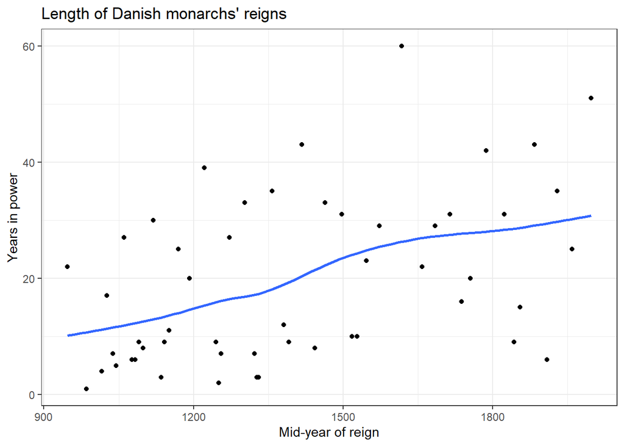

```r
kings %>%
  mutate(midyear = Start_year + (End_year - Start_year) / 2) %>%
  filter(!is.na(midyear), !is.na(duration)) %>%
  ggplot(aes(x = midyear, y = duration)) +
  geom_point() +
  geom_smooth(method = "loess", se = FALSE) +
  labs(
    title = "Length of Danish monarchs' reigns",
    x = "Mid-year of reign",
    y = "Years in power"
  ) +
  theme_bw()
```

A: The plot suggests that reign durations tend to increase over time, with fewer very short reigns in later centuries (probably due to greater political stability and centralisation of power).